# A Situação de Rua entre a Intolerância e a Rejeição nas Ruas do Distrito Federal

Analisando a variação quantitativa de pessoas em situação de rua nas Regiões Administrativas do Distrito Federal no ano 2023

Hernany Gomes de Castro | Doutorando - PPGSOL/UnB e Bruna Guimarães | Aluna especial - IPol/UnB

Agosto/2024

# Reproducibilidade

- O código e os dados utilizados nesse estudo estão disponíveis no repositório público GitHub de Hernany Castro. O arquivo “transito.R” contém o código que permite identificar os demais arquivos necessários para sua reproducibilidade.
- O estudo foi realizado em linguagem R, versão 4.4.1, e software RStudio, com os pacotes tidyverse, dplyr, tidyr, haven, janitor, readxl, magrittr, psych, rmarkdown, tidymodels, FactoMineR e factoextra. O ambiente de trabalho foi configurado em sistema operacional Windows 11.
- O processo de análise envolveu a importação, a transformação e a modelagem dos dados. Um fluxograma estará disponível no arquivo README do repositório.
- Importante ressaltar que o estudo está baseado em um conjunto de dados limitado e pode não ser generalizável para outras populações.

# Objeto

A pesquisa discute a variação quantitativa de pessoas em situação de rua no Distrito Federal no ano 2023.

# Objetivos

- O objetivo geral é mapear possíveis efeitos das políticas públicas sobre a variação quantitativa de pessoas em situação de rua nas regiões administrativas.
- Mais especificamente, analisa-se a variação quantitativa de pessoas em situação de rua aferida pelo Serviço Especializado em Abordagem Social (SEAS), como as variações quantitativas das ações da assistência social, dos boletins de ocorrência policial, dos registros de ouvidoria e dos serviços de limpeza urbana, entre outras.

# Contexto

- A pesquisa atende a um dos requisitos da disciplina Metodologia Quantitativa em Ciência Política, oferecida pelo Programa de Pós-graduação do Instituto de Ciência Política, da Universidade de Brasília (iPol/UnB).
- A participação na disciplina é o cumprimento parcial do requisito optativo do curso de doutorado do Programa de Pó-graduação em Sociologia - PPGSol/UnB. O trabalho apresentando está relacionado à pesquisa de Castro (2023) sobre a situação de rua, em andamento.
- A literatura sobre a situação de rua informa que embora o trânsito entre espaços seja uma das características mais marcantes da situação de rua, não há teorias específicas que o expliquem (Lee et al, 2010).
- Pessoas em situação de rua podem, vez ou outra, residir em imóvel alugado, passar um tempo em abrigos, morar de favor ou ocupar imóveis cedidos quando exercendo atividades laborais. As transições entre diferentes situações de endereço são frequentes, além de ser uma maneira para “dar um tempo” da rua (Shlay e Rossi, 1992).
- No Brasil, Vieira et al (2004) calcula que São Paulo teria aproximadamente 4 milhões de pessoas em situação de rua em 1991, se a definição oficial levasse em conta a dimensão espacial. Por outro lado, Stofells (1977) descreve a ação estatal ostensiva na década de 1970, em São Paulo, para recolher compulsoriamente pessoas em situação de rua.
- E, mais recentemente, Castro (2023) mostra que a situação de endereço das pessoas em situação de rua é utilizada como critério de distribuição diferencial de atendimento pelas políticas públicas de saúde e de assistência social no Distrito Federal.
- Espaço e tempo estão vinculados na situação de rua como dimensões de um mesmo fenômeno. A presente pesquisa é um esforço que contribui para compreender a situação de rua a partir de uma dimensão espacial, em complemento à temporalidade.
- As questões ligadas à situação de rua ganharam relevância social, recentemente, com a decisão liminar do Ministro do STF, Alexandre de Moraes, no âmbito da Arguição de Descumprimento de Preceito Fundamental - [ADPF nº 976](https://portal.stf.jus.br/noticias/verNoticiaDetalhe.asp?idConteudo=512659&ori=1), a qual foi confirmada pelo plenário do STF em 21/08/2023.
- A ADPF se refere as ações de zeladoria pela administração pública, sem observância das diretrizes da Política Nacional para a População em Situação de Rua (Decreto nº 7.053/2009). A decisão determinou a elaboração de um plano de ação e monitoramento pelos Estados, Municípios e o Distrito Federal, para a efeitva implantação da política nacional.

# Metodologia

- Analise-se as direções da variação quantitativa de pessoas em situação de rua e das ações das políticas públicas nas regiões administrativas do Distrito Federal
- A pesquisa foi realizada a partir de dados obtidos mediante acesso à lei de acesso à informação entre janeiro e julho/2024
- Os dados são relativos ao ano 2023
- Amostra:
  - 146 observações (n = 146)
  - 13 variáveis independentes: grupo de RA por renda, atendimentos do centro pop, do creas, da abordagem social, entrega de refeições no centro pop, inscrições e atualizações no cadasrto único, concessão de auxílio vulnerabilidade, coleta total e seletiva de resíduos, registro de ouvidorias e de ocorrências policiais, apreensão de drogas (maconha e cocaína)
  - os dados foram ponderados para cada grupo de 100 habitantes
- Dados analisados com base no Método de Análise de Componentes Principais (PCA)

# Apresentação dos Dados

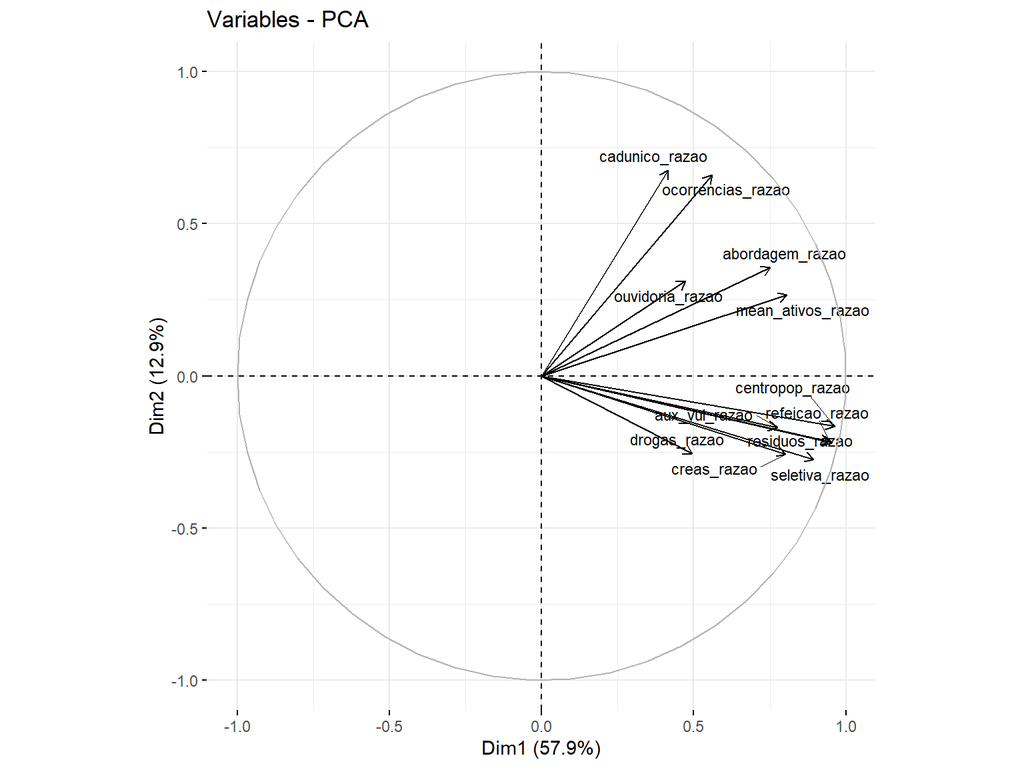

A seguir, discute-se cada uma das dimensões do gráfico.

# Rejeição como Dimensão da Situação de Rua

- A dimensão Rejeição compreende variáveis relacionadas à interação entre vulnerabilidade social e segurança pública. A situação de rua é associada à um sentimento de insegurança.
- Rejeição é uma dimensão que associa a presença de pessoas em situação de rua com ocorrências policiais e ouvidorias. Combinar em uma única dimensão variáveis como ativos e cadastro único, por um lado, abordagem e ouvidorias, por outro, além de ocorrências, sugere o sentimento de rejeição como elemento principal do componente identificado.
- A análise de uma amostra dos registros de ouvidorias do sistema do Governo do Distrito Federal corrobora a compreensão de Rejeição enquanto dimensão que expressa um sentimento de rejeição da população em relação à situação de rua.
- A análise, realizada com apoio do software requalify de Inteligência Artificial (Martins et al, 2024), identificou cinco tags que remetem a um sentido da situação de rua associada como ameaça ao patrimônio, à vida, à saúde e à segurança pública. A situação de rua é vinculada nas ouvidorias à presença de drogas, ao crime, à sujeira e à desordem. As ouvidorias propõem a retirada compulsória das pessoas em situação de rua das áreas públicas, com o objetivo de garantir a segurança e a qualidade de vida das comunidades afetadas.
- As outras duas variáveis dessa dimensão, abordagem social e cadastro único, convergem para o sentimento de rejeição identificado. A variável abordagem social, por exemplo, retrata sua vinculação com as ouvidorias. Isso porque o Serviço Especializado de Abordagem Social no Distrito Federal tem como atribuições responder ouvidorias que envolvam pessoas em situação de rua. A variável cadastro único, por outro lado, expressa sua relação com a variável de ativos, que afere a quantidade de pessoas em situação de rua.
- Rejeição é uma dimensão que expressa o sentimento de rejeição da população em relação à situação de rua, associando vulnerabilidade social e segurança pública. O aumento positivo da variação expressa o aumento do sentimento de rejeição. No gráfico, quanto mais os valores de estão à direita, maior a rejeição da população em relação à situação de rua.
- Entrevistas realizadas por Castro (2023) mostram que é possível encontrar pessoas em situação de rua que não reconhecem sua condição. Lee et al (2010) identificam que pessoas em situação de rua possuem um extenso repertório para gerenciamento de identidade, inclusive negando sua condição na presença de pessoas domiciliadas. As entrevistas realizadas por Castro (2023) mostram que a identificação como trabalhador é um forma utilizada para distinção em relação ao estigma da situação de rua.

# Intolerância como Dimensão da Situação de Rua

- Intolerância é uma dimensão que combina variáveis relativas à vulnerabilidade social com demandas por serviços públicos. Intolerância relativiza o sentimento de rejeição da população aferido em Rejeição, captando a variação da intolerância quando pessoas em situação de rua são alcançadas pelas políticas públicas.
- Intolerância afere a variação do sentimento de rejeição sobre a situação de rua em relação às políticas públicas. Quanto mais os valores de Intolerância escalam a parte superior do gráfico, maior a intolerância.
- Em três das cinco tags identificadas na análise dos registros de ouvidorias, a demanda por serviços públicos está presente. As ouvidorias mostram que a população reconhece a responsabilidade e a ausência do Estado em relação à situação de rua. Por um lado, como forma de assegurar o próprio bem-estar. Por outro, enquanto possibilidade de inclusão social das pessoas em situação de rua. A rejeição da população em relação à situação de rua pode ser atenuada com políticas públicas.
- As entrevistas realizadas por Castro (2023) mostram que o acesso às políticas públicas é um reconhecimento social de cidadania para as pessoas em situação de rua. As políticas públicas facilitam o gerenciamento da identidade pelas pessoas em situação de rua na presença de domiciliados.

# Plano Social Teórico do Trânsito da Situação de Rua

- A PCA permitiu criar um plano social teórico do trânsito da situação de rua. O plano foi carregado com observações de variação associadas aos grupos de região administrativa por renda da população (IPEDF-DIESSE, 2023).
- Os grupos de renda compreendem uma metodologia desenvolvida pelo Instituto de Pesquisa e Estatística do Distrito Federal (IPEDF), em parceria com o Departamento Intersindical de Estatística e Estudos Socioecômicos (DIEESE), para analisar o mercado de trabalho local a partir da dimensão territorial.
- O plano social teórico criado permitiu mapear a posição das regiões administrativas em relação à variação quantitativa das pessoas em situação de rua por grupos de renda.
- Os gráficos, a seguir, mostram a distribuição dos grupos de renda no plano social teórico:

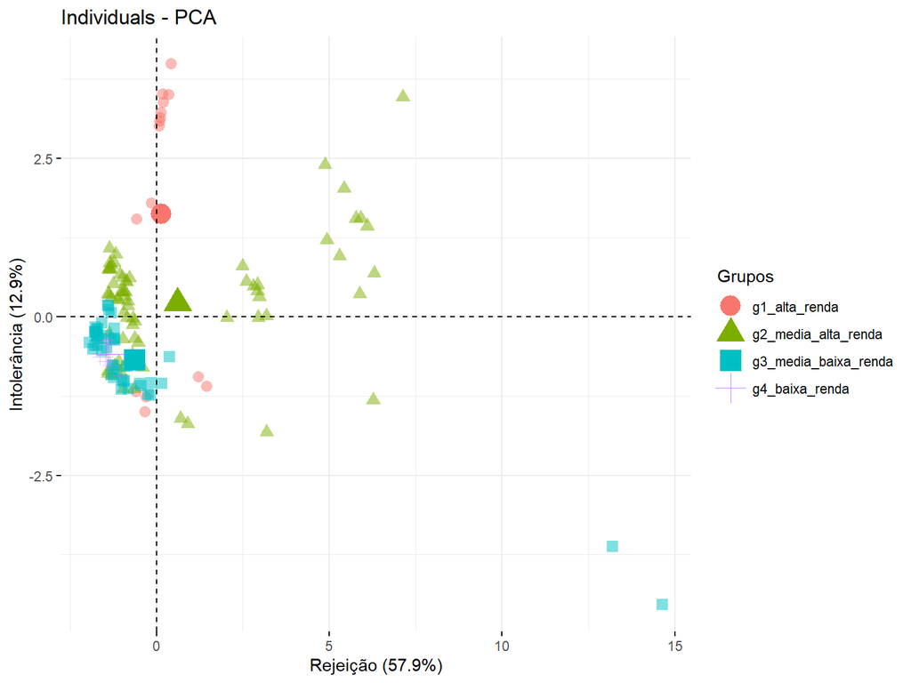

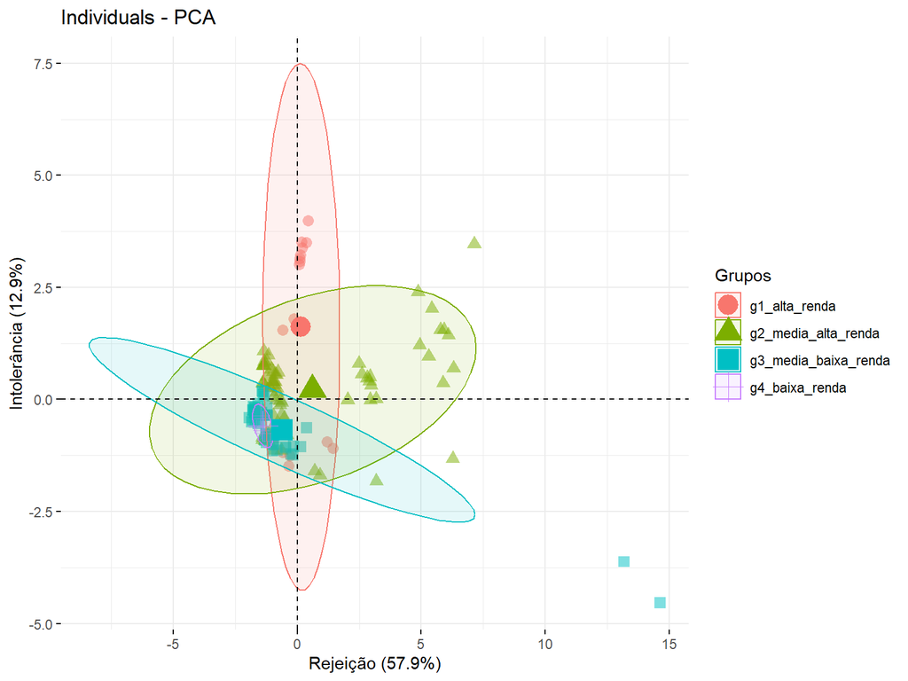